# team.Rmd

Juan Simons; Github: Giltbuckle3, Cole Weber; Github:cpwebs

2/19/2020

```r
dat <- readxl::read_xls('C:/Users/juank/OneDrive/Documents/Actual_DS202_Folder/GSS.xls')
```

```r
library(ggplot2)
library(plyr)
```

## Question 1: How does the happiness of a respondent relate to the marriage status?

There is a clear distinction that married couples are more happy than unhappy. Never married and divorced couples are similar in terms of ratio to married couples, however, there aren’t as many as them. There is, however, a worse off ratio for divorced couples and being unhappy which is something to take away from. This means that the most common category for all three different types of marital status responded with pretty happy.

We chose the variables below based on the idea of simplisity when applicable. This meant that we could drop some columns of data because it was similar to another column. For example, widows and separated are similar to divorced in terms of having been with someone but not currently.

Below are the variables being used and their values.  
Happiness:  
-Not too happy  
-Pretty happy  
-Very happy  
Marital Status:  
-Married  
-Never married  
-Divorced

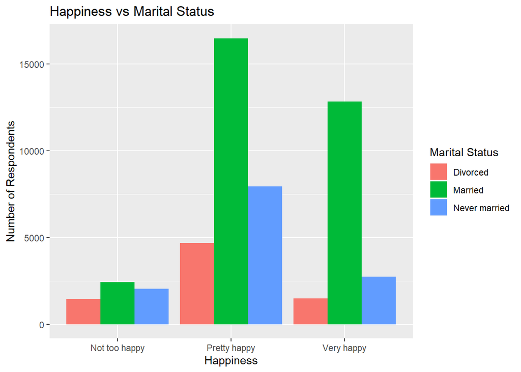

```r
dat1 <-rename(dat, c("Gss year for this respondent" ="Response_year","Respondent id number" = "id_number", "Marital status" = "marital_status", "Respondents sex" = "sex", "Political party affiliation" = "political_affiliation", "General happiness" = "happiness", "Ballot used for interview" = "Ballot" ))

# filtered out widow, separated, no answer (going with three categories of relationship)
# filtered out don't know, no answer, and not applicable since they don't offer insight
dat3Filter <- subset(dat1, marital_status != "Separated" & marital_status != "Widowed" & marital_status != "No answer" & happiness != "No answer" & happiness != "Not applicable" & happiness != "Don't know")

q1 <- ggplot(dat3Filter, aes(happiness, ..count..)) + geom_bar(aes(fill = marital_status), position = "dodge") + labs(x = "Happiness", y = "Number of Respondents", title = "Happiness vs Marital Status",fill = "Marital Status")
q1
```

## Question 2: Does the sex of the respondent affect the relationship you found in Q1?

It seems that the sex didn’t have a strong correlation in relationship to happiness and marriage status. The bar graphs look similar between the two especially in relation to married and never married being super similar. Divorced is very similar as well. With this being said, it looks like people have the same mindset of their marriage status and happiness regardless of sex.

Below are the variables being used and their values.  
Happiness:  
-Not too happy  
-Pretty happy  
-Very happy  
Marital Status:  
-Married  
-Never married  
-Divorced  
Sex:  
-Male  
-Female

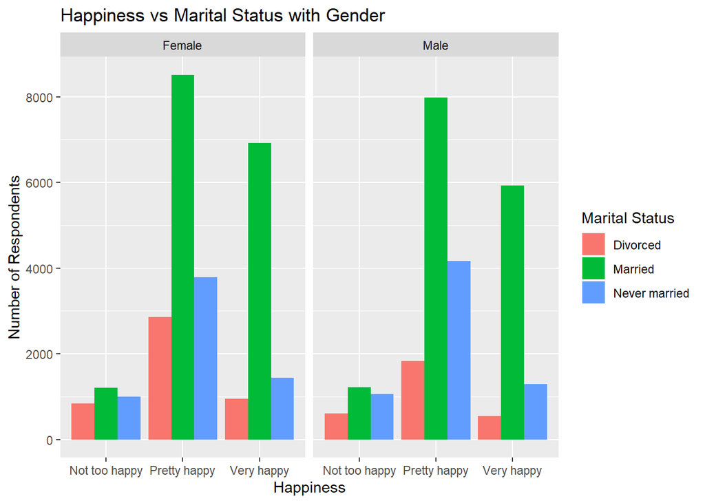

```r
q2 <- ggplot(dat3Filter, aes(happiness, ..count..)) + geom_bar(aes(fill = marital_status), position = "dodge") + labs(x = "Happiness", y = "Number of Respondents", title = "Happiness vs Marital Status with Gender",fill = "Marital Status") + facet_wrap(~sex, scales = "fixed")
q2
```

## Question 3: How does the happiness of a respondent relate to the political party affiliation?

It seems that more respondents are pretty happy more than the other two options. With this being said, not being either a strong democrat or strong republican are the two most popular choices amongst participants. This is in contrast to being strong democrats or republicans because they are generally lesser than the rest of the categories. Being not too happy was unpopular for all participants regardless of political affiliation which goes to show possibly many people are happy with their views and how things are going in their daily lives.

Below are the variables being used and their values.  
Happiness:  
-Not too happy  
-Pretty happy  
-Very happy  
Political Affiliation:  
-Indepedent  
-Not Strong Democrat  
-Not Strong Republican  
-Strong Democrat  
-Strong Republican

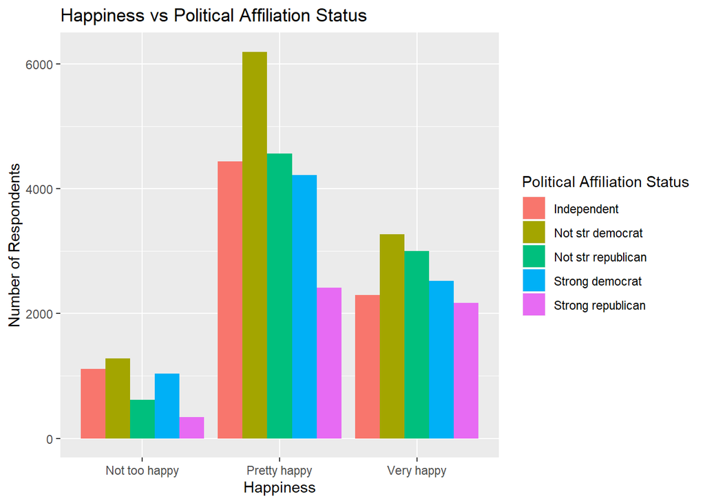

```r
df3 <-subset(dat3Filter, political_affiliation != "Don't know" & political_affiliation != "No answer" & political_affiliation != "Other party" & political_affiliation != "Ind,near rep" & political_affiliation != "Ind,near dem")

q3 <- ggplot(df3, aes(happiness, ..count..)) + geom_bar(aes(fill = political_affiliation), position = "dodge") + labs(x = "Happiness", y = "Number of Respondents", title = "Happiness vs Political Affiliation Status",fill = "Political Affiliation Status")
q3
```